# Some Basics of Descriptive Inference

# An Aside: On “Dummy” Variables

I want to dedicate a special comment here to what are commonly called “dummy” variables. “Dummy” variables (aka binary variables) are variables that take on just two values—functionally 0 or 1. While some dummies have an intuitive order (e.g. “democracy” vs. “not democracy” implies “more democracy”), the phenomenon being measured is strictly “there” or “not there.” This means they are a unique subset of nominal variables, effectively saying they are unordered-categorical with just two categories (“there” or “not there”, “success” vs. “fail”).

That said, I liken them to the carbon or water of the variable world in that they behave in interesting ways and have some interesting peculiarities/properties. With respect to central tendency, the mode and median of a dummy variable will be the same value and the mean will communicate the proportion of 1s. This assumes that your dummies are recoded to 0/1, which you should *always* do. Dummies are often provided to you as 1/2. Always recode those.

Let’s see what this looks like with the `sex` variable in `gss_spending`. `sex` is a numeric vector for the respondent’s sex, either female (1) or male (0).

```r
gss_spending %>%
  # where sex = 1 for women, 0 for men
  summarize(mode = getmode(sex),
            median = median(sex),
            mean = mean(sex))
```

```
## # A tibble: 1 × 3
##    mode median  mean
##   <dbl>  <dbl> <dbl>
## 1     1      1 0.552
```

The above tells me that there are more women than men in the data (the mode), the middlemost observation is a woman on this dummy variable (the median), and that about 55.2% of the observations are women (the mean).

# An Aside: Ordinal or Interval? Or Something Else?

Practitioners love to treat technically ordinal data as interval. There’s more you can do with an interval-level variable than you can with an ordinal (ordered-categorical) variable. However, you have to ask yourself just how advisable this is. For example, take yourself back to college when you just turned 21. Are you truly one year older than your 20-year-old friend when it comes to identification at the off-campus bar? Legally you are, but you might just be three weeks older than your 20-year-old friend. Here, you have information loss in the form of days/weeks. Is someone who lists their yearly income at $50,010 truly 10 dollars richer than someone who lists their yearly income at $50,000? Legally they are (i.e. Uncle Sam cares about dollars, not cents), but you have information loss in the form of cents.

That said, we often describe age by reference to an average and we can (provided there are no major issues of skew) understand an average income. Certainly, practitioners would go-go-gadget a mean on those variables. Here’s a general rule of thumb that I haven’t seen anyone formalize out loud (even if there’s supporting scholarship you’ll read for this) but nonetheless guides how we do this. First, check the number of possible values. Second, check the skew. If you have at least 5—I would caution at least 7, even to 10)—distinct values, you can *start* to think of it as interval. However, check the distribution of the variable. If you have a major skew problem, *don’t* treat it as interval and consider another approach to modeling your variable.

Age is technically ordinal, but there are typically a wide number of distinct ages in survey data spanning from 18 to the 80s and beyond. Therein, differences between observations are granular enough that means with decimals make some sense. Below, the mean is about 48.97. You can reasonably conceptualize that as an average age of 48 that is 97% of the way to turning 49.

```r
gss_spending %>%
  summarize(mean = mean(age, na.rm=T),
            median = median(age, na.rm=T),
            distinct = n_distinct(age))
```

```
## # A tibble: 1 × 3
##    mean median distinct
##   <dbl>  <dbl>    <int>
## 1  49.0     48       73
```

Caveat, naturally: don’t try to explain age as some outcome if you’re thinking ahead to a linear model. Age is a linear function of time. :P

The `sumnat` variable in my `gss_spending` data frame summarizes all responses to spending toward all programs from the ordinal scale provided in the original prompts (again: `?gss_spending` for more). It has a small skew problem to the left, but it’s cast across 33 different values.

```r
gss_spending %>%
  summarize(mean = mean(sumnat, na.rm=T),
            median = median(sumnat, na.rm=T),
            distinct = n_distinct(sumnat))
```

```
## # A tibble: 1 × 3
##    mean median distinct
##   <dbl>  <dbl>    <int>
## 1  6.37      7       33
```

A diagnostic graph doesn’t suggest a major problem for skew either. It’s not a disservice to this variable to summarize it with a mean.

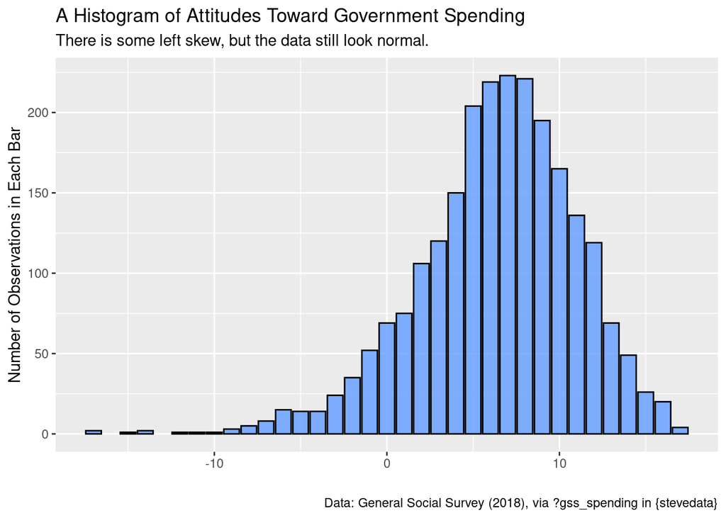

```r
gss_spending %>%
  ggplot(.,aes(sumnat)) +
  geom_bar(alpha=0.8, fill="#619cff",color="black") +
  labs(title = "A Histogram of Attitudes Toward Government Spending",
       subtitle = "There is some left skew, but the data still look normal.",
       caption = "Data: General Social Survey (2018), via ?gss_spending in {stevedata}",
       x = "", y = "Number of Observations in Each Bar")
```

Some variables, however, are too damn ugly to think of as interval the extent to which you want informative means and so on. Here’s an example from the World Values Survey regarding the justifiability of taking a bribe. This is part of a series of World Values Survey items where the researcher lists various behaviors (e.g. abortion, divorce, homosexuality, here: taking a bribe) and the respondent lists how justifiable they think it is on a 1-10 scale. 10 = always justifiable. 1 = never justifiable. Here would be the summary statistics.

```r
wvs_justifbribe %>%
  na.omit %>%
  summarize(mean = mean(f117, na.rm=T),
            median = median(f117, na.rm=T),
            distinct = n_distinct(f117))
```

```
## # A tibble: 1 × 3
##    mean median distinct
##   <dbl>  <dbl>    <int>
## 1  1.80      1       10
```

I’m anticipating a problem here. The mean is almost one off the median with just 10 distinct values. A graph will bring the problem in full light.

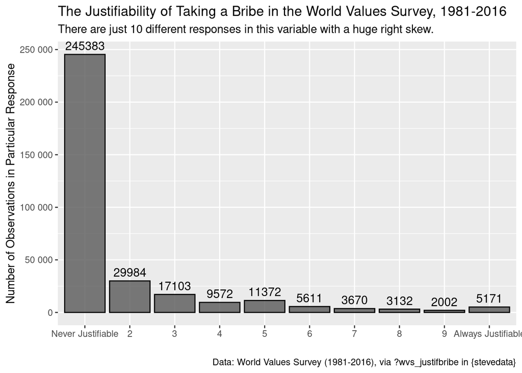

```r
wvs_justifbribe %>%
  count(f117) %>%
  na.omit %>% # count() will also summarize the NAs, which we don't want.
  ggplot(.,aes(as.factor(f117), n)) +
  geom_bar(stat="identity", alpha=0.8, color="black") +
  scale_x_discrete(labels=c("Never Justifiable", "2", "3", "4",
                            "5", "6", "7", "8", "9", "Always Justifiable")) +
  scale_y_continuous(labels = scales::comma_format(big.mark = " ")) +
  geom_text(aes(label=n), vjust=-.5, colour="black",
            position=position_dodge(.9), size=4) +
  labs(y = "Number of Observations in Particular Response",
       x = "",
       title = "The Justifiability of Taking a Bribe in the World Values Survey, 1981-2016",
       caption = "Data: World Values Survey (1981-2016), via ?wvs_justifbribe in {stevedata}",
       subtitle = "There are just 10 different responses in this variable with a huge right skew.")
```

Here’s what I recommend doing in an admittedly extreme situation like this. First, no matter the 10 different values, *don’t* ask for a mean from this. A mean won’t be terribly informative because the data have a huge skew problem and a finite scale of possible responses. Two, the median is at the most you can get here, but I’d caution against treating it as useful information as well. Again, there’s a huge skew. Third, for an extreme situation like this where more than 70% of the data are in just one response, collapse the variable into a dummy variable. In this case, 0 = taking a bribe is never justifiable and 1 = taking a bribe is at least somewhat justifiable. I [did something like this with the exact question](http://svmiller.com/research/external-territorial-threats-and-tolerance-of-corruption-a-privategovernment-distinction/); others have too. Here’s how you’d basically do it. Your data basically look like this.

```r
wvs_justifbribe
```

```
## # A tibble: 348,532 × 6
##     s002  s003 country    s020   uid  f117
##    <dbl> <dbl> <chr>     <dbl> <int> <dbl>
##  1     1    32 Argentina  1984     1     1
##  2     1    32 Argentina  1984     2     1
##  3     1    32 Argentina  1984     3     1
##  4     1    32 Argentina  1984     4     4
##  5     1    32 Argentina  1984     5     5
##  6     1    32 Argentina  1984     6     5
##  7     1    32 Argentina  1984     7     5
##  8     1    32 Argentina  1984     8     4
##  9     1    32 Argentina  1984     9     1
## 10     1    32 Argentina  1984    10     1
## # ℹ 348,522 more rows
```

```r
wvs_justifbribe %>%
  mutate(never_justifiable = ifelse(f117 == 1, 1, 0),
         somewhat_justifiable = ifelse(f117 == 1, 0, 1))
```

```
## # A tibble: 348,532 × 8
##     s002  s003 country   s020   uid  f117 never_justifiable somewhat_justifiable
##    <dbl> <dbl> <chr>    <dbl> <int> <dbl>             <dbl>                <dbl>
##  1     1    32 Argenti…  1984     1     1                 1                    0
##  2     1    32 Argenti…  1984     2     1                 1                    0
##  3     1    32 Argenti…  1984     3     1                 1                    0
##  4     1    32 Argenti…  1984     4     4                 0                    1
##  5     1    32 Argenti…  1984     5     5                 0                    1
##  6     1    32 Argenti…  1984     6     5                 0                    1
##  7     1    32 Argenti…  1984     7     5                 0                    1
##  8     1    32 Argenti…  1984     8     4                 0                    1
##  9     1    32 Argenti…  1984     9     1                 1                    0
## 10     1    32 Argenti…  1984    10     1                 1                    0
## # ℹ 348,522 more rows
```

You want to use the `mutate()` function to create a dummy variable whereby if `f117` is 1, it’s 0. If it’s greater than 1, code it as 1. Let’s use the `mutate()` wrapper to create a new `bribe_dummy` variable that has this information. Pay careful attention to what the `case_when()` function is doing in this context.

```r
# Take our data frame, and...
wvs_justifbribe %>%
  # use the mutate() function to create a new column, using case_when(), where...
  mutate(bribe_dummy = case_when(
    # if f117 == 1, it's 0
    f117 == 1 ~ 0,
    # if it's f117 > 1 (or %in% c(2:10)), it's 1
    f117 > 1  ~ 1,
    # if it's anything else (here: NA), keep it as NA.
    TRUE ~ NA_real_
  )) -> Data # Create a new data object for now.
```

Let’s see what this did.

```r
Data %>%
  distinct(f117, bribe_dummy)
```

```
## # A tibble: 11 × 2
##     f117 bribe_dummy
##    <dbl>       <dbl>
##  1     1           0
##  2     4           1
##  3     5           1
##  4     6           1
##  5     2           1
##  6     3           1
##  7    NA          NA
##  8     7           1
##  9     8           1
## 10     9           1
## 11    10           1
```

Congrats on recoding your first variable! Notice too how you created a new column that did not overwrite the original, so you can always troubleshoot what you did to see if you messed up somewhere. Btw, since I know this is going to be something you’ll need to know to do for a homework question I’ll ask, let’s assume we’re interested in those that are `NA` here. `NA` can mean multiple things, but what if we just assume that they’re people that are withholding what they think about taking a bribe and we want to perhaps understand that as a kind of dependent variable? Here’s how we’d do that.

```r
# Taking our data frame, and...

Data %>%
  # ...using mutate() to create a new column in the data where,
  # using case_when()
  mutate(missing_f117 = case_when(
    # if it's missing, it's a 1
    is.na(f117) ~ 1,
    # if it's anything else (`TRUE` in case_when() speak), it's 0
    TRUE ~ 0
  )) -> Data # assign to object
```

Let’s see what this did.

```r
Data %>%
  distinct(f117, missing_f117)
```

```
## # A tibble: 11 × 2
##     f117 missing_f117
##    <dbl>        <dbl>
##  1     1            0
##  2     4            0
##  3     5            0
##  4     6            0
##  5     2            0
##  6     3            0
##  7    NA            1
##  8     7            0
##  9     8            0
## 10     9            0
## 11    10            0
```